# Profitability Analysis Report

## 2.2 Opportunity Cost Curve

[output not shown]

### 2.2.2 Table

[output not shown]

[output cut: 58 more lines]

## 2.3 Net Present Value Maps

The NPV Maps are critical visual outputs that illustrate the financial performance of different land-use categories at two distinct points in time. These maps help in understanding how land-use changes over time impact profitability, providing valuable insights for decision-makers seeking to balance economic and environmental factors.

### 2.3.1 NPV Map for Year 1990

This map serves as a baseline for understanding the initial profitability of different land uses before any land-use changes occur. The map visually displays areas with varying degrees of profitability, using color gradients to indicate the range of NPV values.

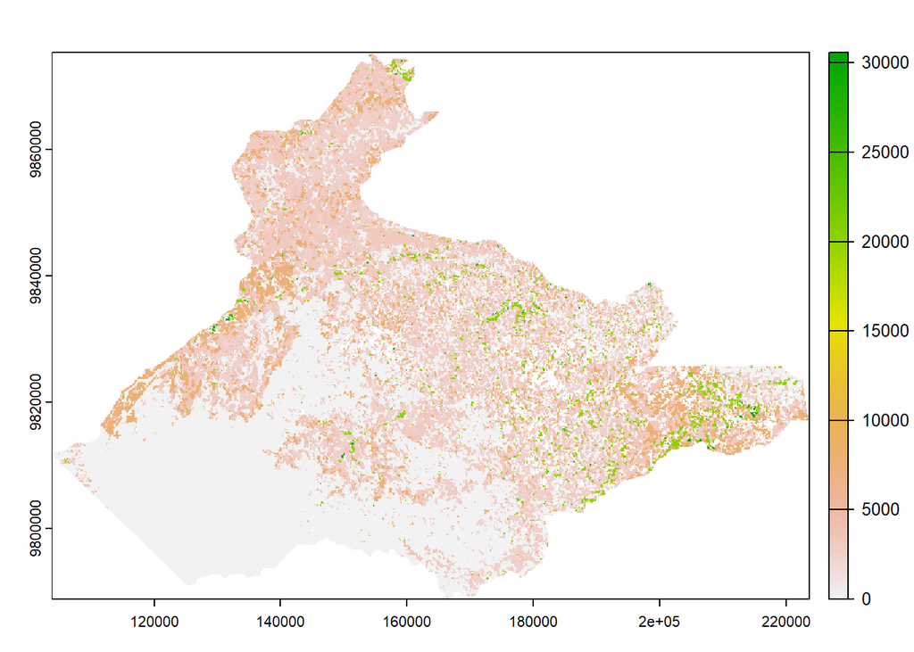